# Superdense Coding

Study Notes for Superdense coding

Jay (notetaker)

last updated on: 2021-11-21

Notes source:

1. [qiskit textbook](https://learn.qiskit.org/course/introduction/entangled-states#entangled-30-0)
2. [qiskit textbook (the old one)](https://qiskit.org/textbook/ch-algorithms/superdense-coding.html)
3. [Michael Nielsen Video](https://www.youtube.com/watch?v=w5rCn593Dig)

In classical information, we can send no more than $n$ bits of information if we only send $n$ bits. In q information, similarly, no more than $n$ bits of (classical) information can be encoded and retrieved from $n$ qubits.

However, if two qubits are entangled and each given to a person, there is a communication protocol/procedure such that one person can send 2 bits of classical information to the other person by just sending one qubit. This is known as superdense coding.

Let say Alice wants to send 2 classical bit to Bob.

**Method 1**

Encode 2 classical bits using 2 qubits.

```python
from qiskit import QuantumCircuit, Aer

# The message
MESSAGE = '00'

# Alice encodes the message
qc_alice = QuantumCircuit(2, 2) # 2 qubits and 2 classical bits
if MESSAGE[-1]=='1':
    _ = qc_alice.x(0)
if MESSAGE[-2]=='1':
    _ = qc_alice.x(1)

backend = Aer.get_backend('aer_simulator')

# Bob measures
qc_bob = QuantumCircuit(2, 2)

# use _= to suppress return value being printed
# measure qubits 0 & 1 to classical bits 0 & 1
_ = qc_bob.measure([0, 1],[0, 1])

backend.run(qc_alice.compose(qc_bob)).result().get_counts()
## {'00': 1024}
```

**Method 2**

Encode 2 classical bits using 2 qubits, but insert entanglement.

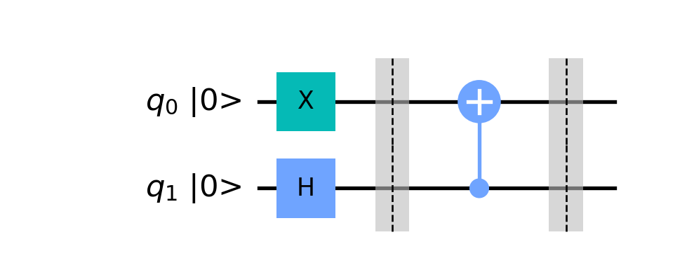

Recall: Construct a Bell state to send message ‘01’

$$H|0\rangle = |+\rangle = \frac{1}{\sqrt{2}}(|0\rangle+|1\rangle)
= \frac{1}{\sqrt{2}}
\begin{bmatrix}
1 \\
1
\end{bmatrix}$$
$$|+\rangle \otimes |1\rangle = |+1\rangle
= \frac{1}{\sqrt{2}}(|01\rangle+|11\rangle)|
= \frac{1}{\sqrt{2}}
\begin{bmatrix}
0 \\
1 \\
0 \\
1
\end{bmatrix}$$
$$CNOT|+1\rangle
= \frac{1}{\sqrt{2}}(|01\rangle+|10\rangle)
= \frac{1}{\sqrt{2}}
\begin{bmatrix}
0 \\
1 \\
1 \\
0
\end{bmatrix}$$

```python
from qiskit import QuantumCircuit, Aer
from qiskit.quantum_info import Statevector

MESSAGE = '01'

qc_alice = QuantumCircuit(2, 2)

# Alice encodes the message
if MESSAGE[-1]=='1':
    _ = qc_alice.x(0)
if MESSAGE[-2]=='1':
    _ = qc_alice.x(1)

# then she creates entangled states
_ = qc_alice.h(1)
_ = qc_alice.cx(1, 0)

ket = Statevector(qc_alice)
print(ket.draw('latex_source'))
```

$$\begin{bmatrix}
0 & \tfrac{1}{\sqrt{2}} & \tfrac{1}{\sqrt{2}} & 0 \\
\end{bmatrix}$$

Bob un-entangls and measures what Alice send.

```python
# Bob: un-entangle and measure
qc_bob = QuantumCircuit(2, 2)

# Bob unentangles
_ = qc_bob.cx(1, 0)
_ = qc_bob.h(1)

# Then measures
qc_bob.measure([0, 1],[0, 1]);

backend = Aer.get_backend('aer_simulator')
backend.run(qc_alice.compose(qc_bob)).result().get_counts()
## {'01': 1024}
```

**Method 3**

In method 2, Alice prepares the following entangled states depending on which two classical bits she wants to send.

$$00 \rightarrow |\Phi^+\rangle = \frac{1}{\sqrt{2}}(|00\rangle + |11\rangle) \\
01 \rightarrow |\Psi^+\rangle = \frac{1}{\sqrt{2}}(|01\rangle + |10\rangle) \\
10 \rightarrow |\Phi^-\rangle = \frac{1}{\sqrt{2}}(|00\rangle - |11\rangle) \\
11 \rightarrow |\Psi^-\rangle = \frac{1}{\sqrt{2}}(|01\rangle - |10\rangle)$$
Let’s say we start with the following entangled state (prepared by a thrid party, Charlie).

$$|\Phi^+\rangle = \frac{1}{\sqrt{2}}(|0_A0_B\rangle + |1_A1_B\rangle)$$

Note that in order to prepare any of the above four different states, Alice just need to manipulate one qubit ($q_A$) of the entangled states.

$$X|0\rangle = |1\rangle, X|1\rangle = |0\rangle \\
Z|0\rangle = |0\rangle, Z|1\rangle = -|1\rangle$$

$$\begin{aligned}
00 &\rightarrow I: I(|\Phi^+\rangle) = |\Phi^+\rangle \\
01 &\rightarrow X: X_A(|\Phi^+\rangle) = |\Psi^+\rangle \\
10 &\rightarrow Z: Z_A(|\Phi^+\rangle) = |\Phi^-\rangle \\
11 &\rightarrow ZX: Z_AX_A(|\Phi^+\rangle) = |\Psi^-\rangle
\end{aligned}$$

This implies that the following communication protocol would work. Charlie, a third party, can prepare ahead an entangled state and send one qubit to Alice and the other to Bob. Alice manipulates the quibt she gets depending on the classical bits she intends to send. She then send the resulting qubit to Bob. Bob can recover the two classical bits Alice intends to send as he did in method 2.

One qubit is sent for 2 classical bits of information. This is something classical computer cannot do, although the protocol as a whole still requires two qubits.

```python
from qiskit import QuantumCircuit, Aer
from qiskit.quantum_info import Statevector

# Charlie prepares an entangled state, and send
# one qubit to Alice and the other to Bob
qc_charlie = QuantumCircuit(2,2)

_ = qc_charlie.h(1)
_ = qc_charlie.cx(1,0)

_ = qc_charlie.barrier()

# Alice manipulate her qubit accordingly, and send it Bob
MESSAGE = '01'

qc_alice = QuantumCircuit(2,2)

if MESSAGE[-2]=='1':
    _ = qc_alice.z(1)
if MESSAGE[-1]=='1':
    _ = qc_alice.x(1)

_ = qc_alice.barrier()

# Bob unentangles the two quibits and decodes the message
qc_bob = QuantumCircuit(2,2)
# Bob unentangles
_ = qc_bob.cx(1, 0)
_ = qc_bob.h(1)
# Then measures
qc_bob.measure([0, 1],[0, 1]);

complete_qc = qc_charlie.compose(qc_alice.compose(qc_bob))
backend.run(complete_qc).result().get_counts()
```

```
## {'01': 1024}
```

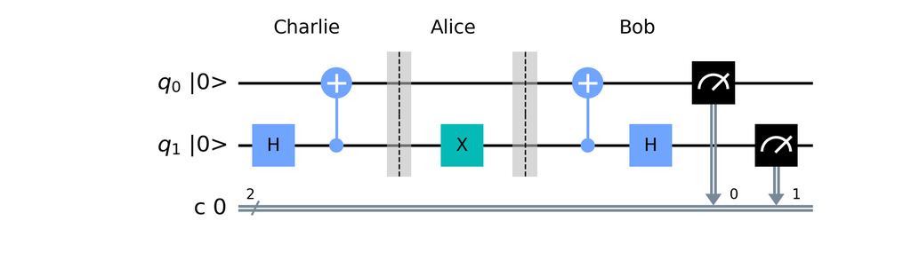